# Clustering ’Student Alcohol consumption

Bedil Karimov

## Clustering

Certainly we face clustering in most of the situations in daily challenges related to data. Clustering is an attempt to structure the objects depending on the specific rule defining intrasimilarity of the objects. Here it deals with the big datasets consisting of multiple features. Thanks to the developments in IT industry the computation procedure became easy and lead us to easily use clustering and utilize data in a more efficient way using different types of algorithms. Many experts performing in the fields of statistics, AI, machine learning and Big Data are actively making use of clustering. Here we can mention two specific types of clustering: hierarchical and flat clustering, where each differs depending on the algorithms that it makes use of. In the former one the hierarchy of clusters visualized as a tree of clusters is made, whereas in the latter one we can see the creation of the set of clusters without any transparent structure. The mostly used and popular methods of clustering are: kmeans,Clustering of Large Applications (CLARA), kmedoids and Hierarchical.

## Dataset - Student Alcohol Consumption

```r
alco <- read.csv('student-por.csv')
summary(alco)
```

```
##  school   sex          age        address famsize   Pstatus
##  GP:423   F:383   Min.   :15.00   R:197   GT3:457   A: 80
##  MS:226   M:266   1st Qu.:16.00   U:452   LE3:192   T:569
##                   Median :17.00
##                   Mean   :16.74
##                   3rd Qu.:18.00
##                   Max.   :22.00
##       Medu            Fedu             Mjob           Fjob
##  Min.   :0.000   Min.   :0.000   at_home :135   at_home : 42
##  1st Qu.:2.000   1st Qu.:1.000   health  : 48   health  : 23
##  Median :2.000   Median :2.000   other   :258   other   :367
##  Mean   :2.515   Mean   :2.307   services:136   services:181
##  3rd Qu.:4.000   3rd Qu.:3.000   teacher : 72   teacher : 36
##  Max.   :4.000   Max.   :4.000
##         reason      guardian     traveltime      studytime
##  course    :285   father:153   Min.   :1.000   Min.   :1.000
##  home      :149   mother:455   1st Qu.:1.000   1st Qu.:1.000
##  other     : 72   other : 41   Median :1.000   Median :2.000
##  reputation:143                Mean   :1.569   Mean   :1.931
##                                3rd Qu.:2.000   3rd Qu.:2.000
##                                Max.   :4.000   Max.   :4.000
##     failures      schoolsup famsup     paid     activities nursery
##  Min.   :0.0000   no :581   no :251   no :610   no :334    no :128
##  1st Qu.:0.0000   yes: 68   yes:398   yes: 39   yes:315    yes:521
##  Median :0.0000
##  Mean   :0.2219
##  3rd Qu.:0.0000
##  Max.   :3.0000
##  higher    internet  romantic      famrel         freetime
##  no : 69   no :151   no :410   Min.   :1.000   Min.   :1.00
##  yes:580   yes:498   yes:239   1st Qu.:4.000   1st Qu.:3.00
##                                Median :4.000   Median :3.00
##                                Mean   :3.931   Mean   :3.18
##                                3rd Qu.:5.000   3rd Qu.:4.00
##                                Max.   :5.000   Max.   :5.00
##      goout            Dalc            Walc          health
##  Min.   :1.000   Min.   :1.000   Min.   :1.00   Min.   :1.000
##  1st Qu.:2.000   1st Qu.:1.000   1st Qu.:1.00   1st Qu.:2.000
##  Median :3.000   Median :1.000   Median :2.00   Median :4.000
##  Mean   :3.185   Mean   :1.502   Mean   :2.28   Mean   :3.536
##  3rd Qu.:4.000   3rd Qu.:2.000   3rd Qu.:3.00   3rd Qu.:5.000
##  Max.   :5.000   Max.   :5.000   Max.   :5.00   Max.   :5.000
##     absences            G1             G2              G3
##  Min.   : 0.000   Min.   : 0.0   Min.   : 0.00   Min.   : 0.00
##  1st Qu.: 0.000   1st Qu.:10.0   1st Qu.:10.00   1st Qu.:10.00
##  Median : 2.000   Median :11.0   Median :11.00   Median :12.00
##  Mean   : 3.659   Mean   :11.4   Mean   :11.57   Mean   :11.91
##  3rd Qu.: 6.000   3rd Qu.:13.0   3rd Qu.:13.00   3rd Qu.:14.00
##  Max.   :32.000   Max.   :19.0   Max.   :19.00   Max.   :19.00
```

```r
head(alco)
```

```
##   school sex age address famsize Pstatus Medu Fedu     Mjob     Fjob
## 1     GP   F  18       U     GT3       A    4    4  at_home  teacher
## 2     GP   F  17       U     GT3       T    1    1  at_home    other
## 3     GP   F  15       U     LE3       T    1    1  at_home    other
## 4     GP   F  15       U     GT3       T    4    2   health services
## 5     GP   F  16       U     GT3       T    3    3    other    other
## 6     GP   M  16       U     LE3       T    4    3 services    other
##       reason guardian traveltime studytime failures schoolsup famsup paid
## 1     course   mother          2         2        0       yes     no   no
## 2     course   father          1         2        0        no    yes   no
## 3      other   mother          1         2        0       yes     no   no
## 4       home   mother          1         3        0        no    yes   no
## 5       home   father          1         2        0        no    yes   no
## 6 reputation   mother          1         2        0        no    yes   no
##   activities nursery higher internet romantic famrel freetime goout Dalc
## 1         no     yes    yes       no       no      4        3     4    1
## 2         no      no    yes      yes       no      5        3     3    1
## 3         no     yes    yes      yes       no      4        3     2    2
## 4        yes     yes    yes      yes      yes      3        2     2    1
## 5         no     yes    yes       no       no      4        3     2    1
## 6        yes     yes    yes      yes       no      5        4     2    1
##   Walc health absences G1 G2 G3
## 1    1      3        4  0 11 11
## 2    1      3        2  9 11 11
## 3    3      3        6 12 13 12
## 4    1      5        0 14 14 14
## 5    2      5        0 11 13 13
## 6    2      5        6 12 12 13
```

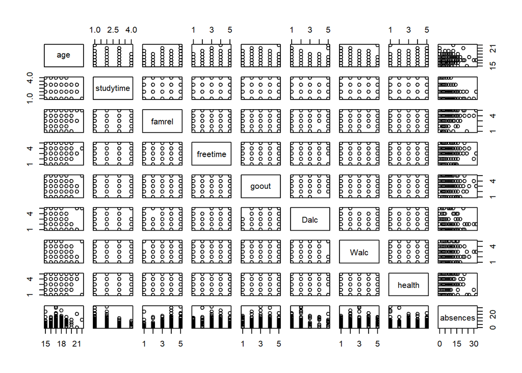

```r
alcol = subset(alco, select = c(age, studytime, famrel, freetime, goout, Dalc, Walc, health, absences))

plot(alcol)
```

Before we go further let us check how good is our dataset to be clustered. Here we use the Hopkins statistic which reflects the clustering tendency of data. The robustness level of clustering of data ranges from 0 (low) to 1 (highest).

```r
alco_a <- hopkins(alcol, nrow(alcol)-1)
cat("Hopkins statistics is",alco_a$H)
```

```
## Hopkins statistics is 0.3327563
```

Even though our Hopkins statistics is 0.33, showing that it is moderately distributed and has no significant clustering feature, we proceed with our analysis of data.

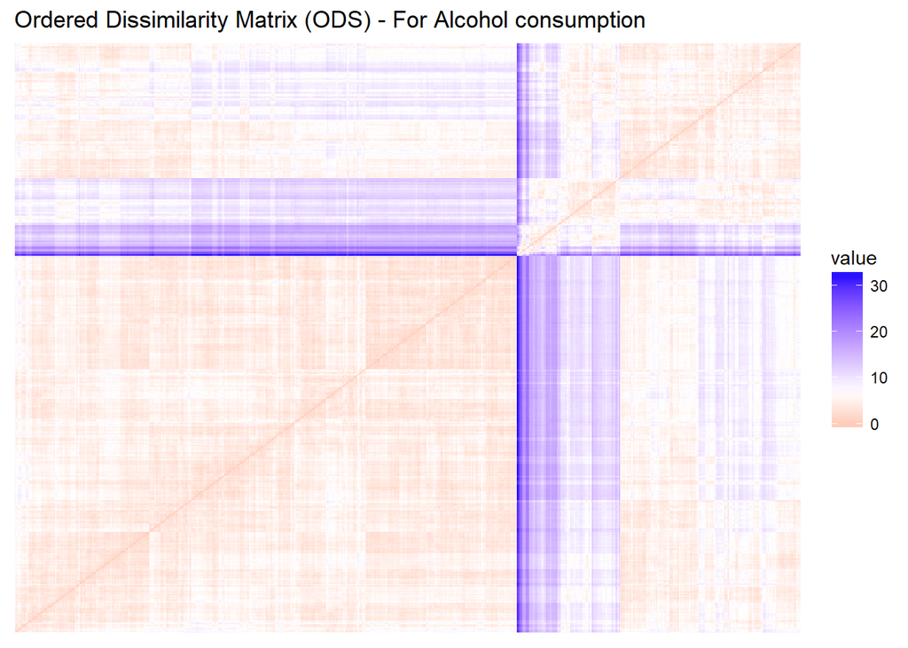

```r
a <- get_dist(alcol, method = "euclidean")
fviz_dist(a, show_labels = F) + labs(title = "Ordered Dissimilarity Matrix (ODS) - For Alcohol consumption")
```

Above in (ODS) we can see how clusters of data are placed, where red ones are close ones and blue one shows distant observations. Here we can easily distinguish the clusters separated by colors.

Now, another step is to find the optimal number of cluster depending on the level of silhouette statistics, which is between -1 (the most undesirable) and 1 (the most desirable).

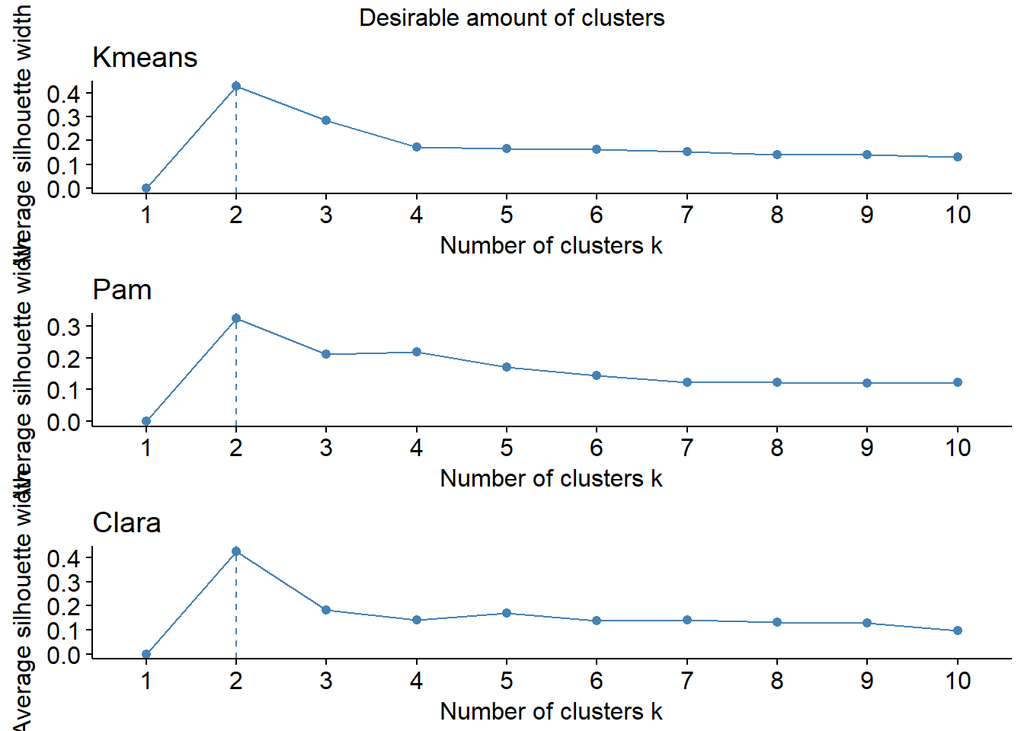

```r
d <- fviz_nbclust(alcol,FUNcluster=kmeans, method = "s") + labs(title = "Kmeans")
f <- fviz_nbclust(alcol,FUNcluster=pam, method = "s") + labs(title = "Pam")
g <- fviz_nbclust(alcol,FUNcluster=clara, method = "s") + labs(title = "Clara")

grid.arrange(d, f, g, top = "Desirable amount of clusters")
```

We can easily notice that the one with the highest silhoutte is the most reliable choice. Thus we optimal number of clusters to find is 2, which will be used from now on.

Next thing is the primary goal of our analysis which is to cluster data accordigly. After applying the algorithms, it seems that the split into two is similar among the methods.

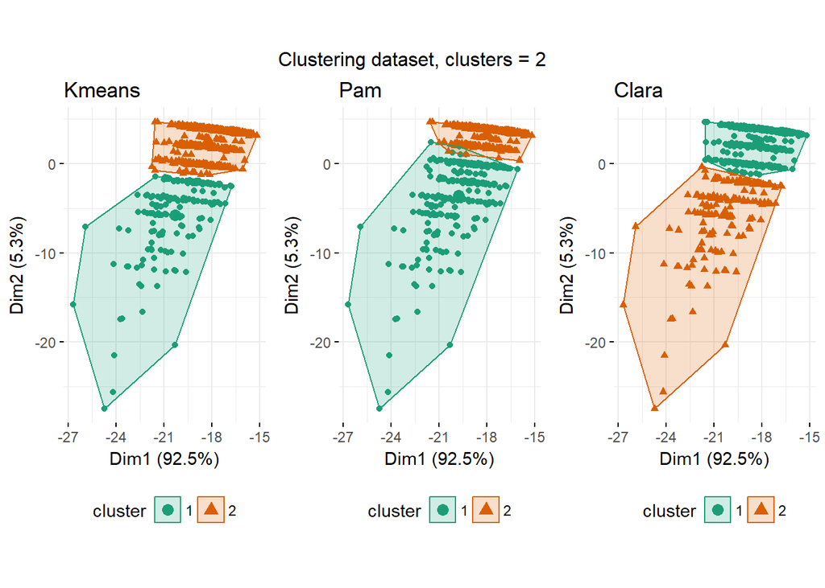

```r
cl_num <- 2

km <- kmeans(alcol, cl_num)
kmp <- fviz_cluster(list(data=alcol, cluster=km$cluster), ellipse.type="convex", geom="point", stand=FALSE, palette="Dark2", ggtheme=theme_minimal()) + labs(title = "Kmeans")+theme(legend.position="bottom")

pamc <- pam(alcol, cl_num)
pamp <- fviz_cluster(list(data=alcol, cluster=pamc$clustering), ellipse.type="convex", geom="point", stand=FALSE, palette="Dark2", ggtheme=theme_minimal()) + labs(title = "Pam")+theme(legend.position="bottom")

claa <- clara(alcol, cl_num)
claap <- fviz_cluster(list(data = alcol, cluster = claa$clustering),ellipse.type = "convex", geom="point", stand = FALSE, palette = "Dark2", ggtheme = theme_minimal()) + labs(title = "Clara")+theme(legend.position="bottom")

grid.arrange(kmp,pamp,claap,heights=unit(0.8, "npc") , top = "Clustering dataset, clusters = 2")
```

Below we also have a Silhouette diagram for other two methods, PAM and CLARA, where it seems that CLARA is better, because it has created clusters that are more homogenous inside and heterogeneous outside. The first observations that are the closest to the center of a cluster have high silhouettes, and those that lie far from the center have small or even negative silhouettes. It clearly be seen that the CLARA is better in the aspect of differentiation due to the homogeneity and heterogeneity.

```r
slh_pam <- fviz_silhouette(pamc) + labs(title = "PAM")
```

```
##   cluster size ave.sil.width
## 1       1  281          0.11
## 2       2  368          0.49
```

```r
slh_claa <- fviz_silhouette(claa) + labs(title = "CLARA")
```

```
##   cluster size ave.sil.width
## 1       1   31          0.41
## 2       2   13          0.23
```

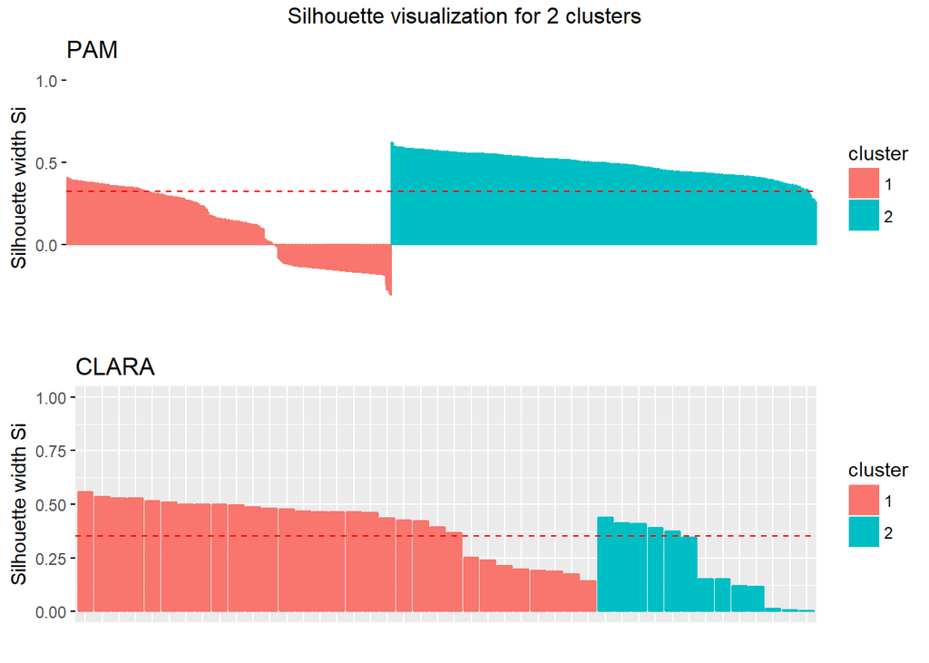

```r
grid.arrange(slh_pam,slh_claa,top = "Silhouette visualization for 2 clusters")
```

## Dendogram clustering

Here we have the hierarchical type of clustering where we can notice the creation of the hierarchy of clusters. In our dataset we have the hierarhy of a second level. But it becomes highly unreadable after 4th level.

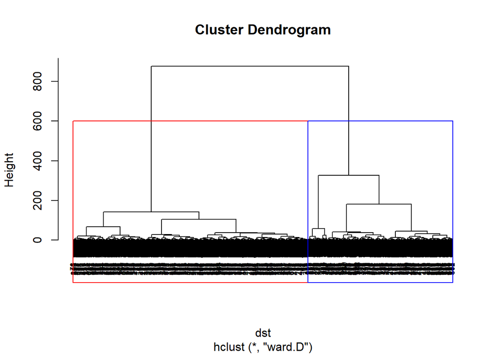

```r
dst <- dist(alcol, method = "euclidean")
res <- hclust(dst, method = "ward.D" )
total <- cutree(res, k = 2)
plot(res, cex = 0.6)
rect.hclust(res, k = 2, border = c('red','blue'))
```

## Boxplot distribution

Below we can see the distribution of data, especially the median and the spread of data that we possess. We can see that both of the clusters are more or less distributed in the same way, but still the first one looks distributed in a more favorable way.

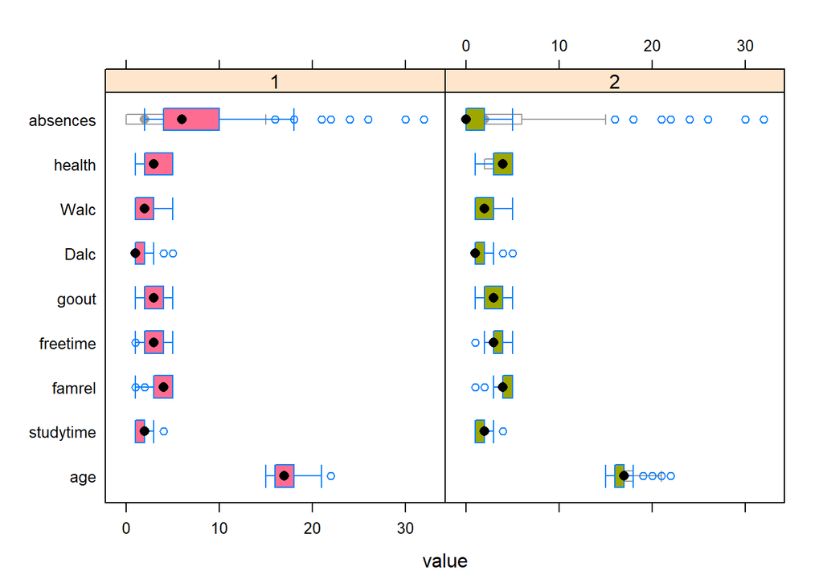

```r
groupBWplot(alcol, as.factor(total), alpha=0.05)
```

## Final conclusion

```r
analyse <- clValid(alcol, nClust = 2:4, clMethods = c("hierarchical", "kmeans", "pam", "clara","fanny"), validation = "internal",maxitems = 1000 )
summary(analyse)
```

```
##
## Clustering Methods:
##  hierarchical kmeans pam clara fanny
##
## Cluster sizes:
##  2 3 4
##
## Validation Measures:
##                                   2        3        4
##
## hierarchical Connectivity    5.9754  54.3183  72.7028
##              Dunn            0.2493   0.1116   0.1571
##              Silhouette      0.7077   0.4525   0.3667
## kmeans       Connectivity   40.9425  73.6960  98.4774
##              Dunn            0.0558   0.0718   0.1132
##              Silhouette      0.4769   0.3649   0.3322
## pam          Connectivity   44.0278 143.3667 164.8480
##              Dunn            0.0461   0.0400   0.0538
##              Silhouette      0.3245   0.2117   0.2180
## clara        Connectivity   49.7063 168.6544 257.0321
##              Dunn            0.0724   0.0372   0.0424
##              Silhouette      0.4268   0.1818   0.1418
## fanny        Connectivity   38.4734  78.6218       NA
##              Dunn            0.0698   0.0512       NA
##              Silhouette      0.3296   0.1850       NA
##
## Optimal Scores:
##
##              Score  Method       Clusters
## Connectivity 5.9754 hierarchical 2
## Dunn         0.2493 hierarchical 2
## Silhouette   0.7077 hierarchical 2
```

Student Alcohol Consumption: https://www.kaggle.com/uciml/student-alcohol-consumption